# Glejak Part II

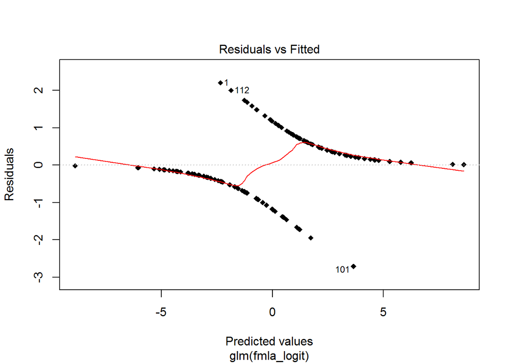

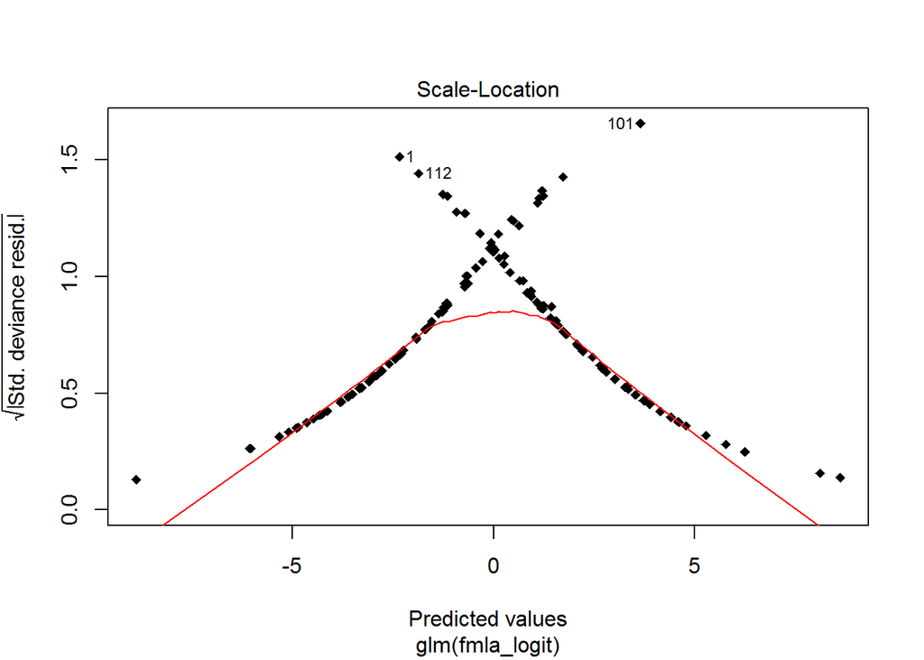

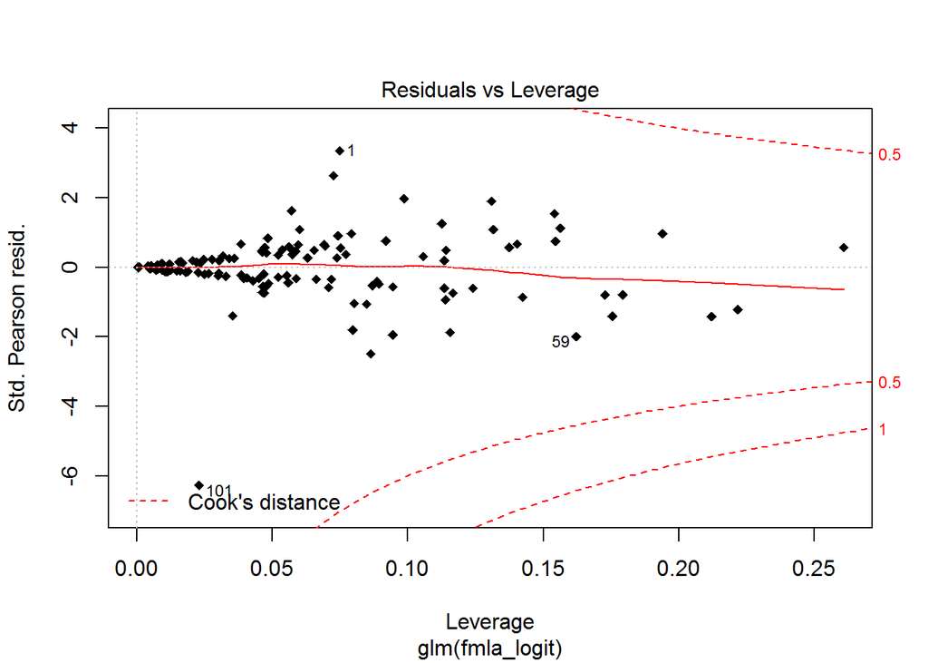

```r
plot(logit, c(1,3,5), pch=18)
```

## 2.1.2 Drzewo decyzyjne

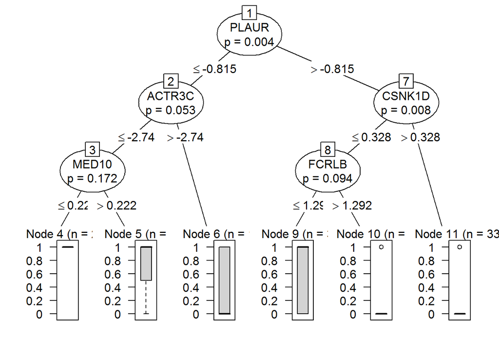

```r
library("party")
topgenes<-as.character(topgenes)
fmla <-as.formula(paste("death1y ~ ", paste(topgenes, collapse= "+")))
drzewo<-ctree(fmla,d, controls = ctree_control(mincriterion=(0.8)))
plot(drzewo)
```

# 2.2 Weryfikacja klasyfikatorów

## 2.2.1 k-krotna powtórzona walidacja krzyżowa

Będziemy używać k = 5, co podzieli nam zbiór pacjentów na 5 równolicznych części. Dla każdej z części będziemy sprawdzać efektywność klasyfikatorów przyuczonych na pozostałych 4 częściach. Dla obu klasyfikatorów robimy 50 takich losowych podziałów, a na końcu wyświetlamy histogramy które dadzą nam możliwość porównania ich efektywności.

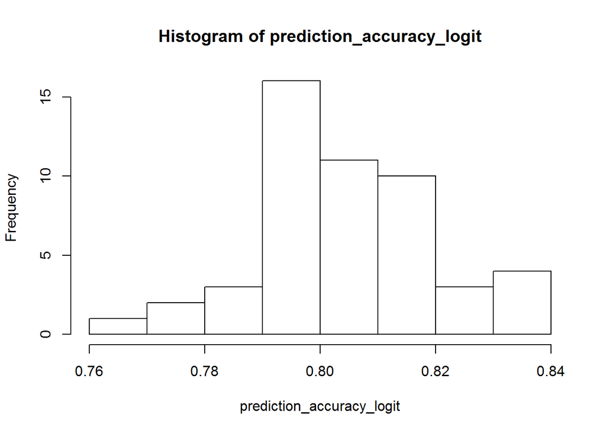

```r
set.seed(1)
prediction_accuracy_logit <- NULL
prediction_accuracy_ctree <- NULL
for (k in 1:50){
  x <- sample(1:125)
  well_predicted_logit <- 0
  well_predicted_ctree <- 0
  for (i in 0:4) {
    rg <- (25*i+1):(25*(i+1))
    x1 <- x[rg]
    x2 <- x[-(rg)]
    test_set <- d[x1,]
    training_set <- d[x2,]

    logit <- glm(fmla_logit, family='binomial', training_set)
    drzewo <- ctree(fmla, training_set, controls = ctree_control(mincriterion=(0.8)))

    predicted_probabilities_logit <- predict(logit, test_set, type = "response")
    predicted_probabilities_ctree <- as.numeric(predict(drzewo, test_set))
    expected_values <- test_set$death1y
    for (j in 1:25) {
      if (predicted_probabilities_logit[j] > 0.5 && expected_values[j]) {
        well_predicted_logit <- well_predicted_logit + 1
      } else if (predicted_probabilities_logit[j] <= .5 && !expected_values[j]) {
        well_predicted_logit <- well_predicted_logit + 1
      }
      if (predicted_probabilities_ctree[j] > 0.5 && expected_values[j]) {
        well_predicted_ctree <- well_predicted_ctree + 1
      } else if (predicted_probabilities_ctree[j] <= .5 && !expected_values[j]) {
        well_predicted_ctree <- well_predicted_ctree + 1
      }
    }
  }
  prediction_accuracy_logit <- c(prediction_accuracy_logit, well_predicted_logit/125)
  prediction_accuracy_ctree <- c(prediction_accuracy_ctree, well_predicted_ctree/125)
}
hist(prediction_accuracy_logit)
```

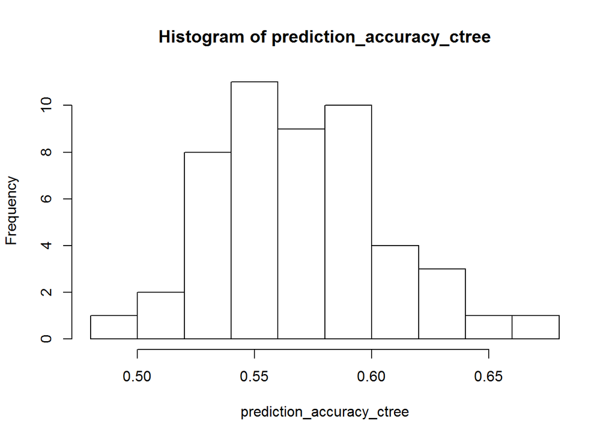

```r
hist(prediction_accuracy_ctree)
```

Możemy zauważyć, że regresja logistyczna klasyfikuje dane poprawnie dużo częściej niż drzewo decyzyjne.

## 2.2.2 Krzywa ROC

Do porównania obu klasyfikatorów użyjemy także krzywej ROC. Dla ustalonego progu decyzyjnego w klasyfikatorze krzywa ROC mówi jaka jest proporcja liczby osób zaklasyfikowanych jako zmarłe w ciągu przyszłego roku w stosunku do osób faktycznie zmarłych oraz jaka jest proporcja liczby osób zaklasyfikowanych jako żywe w ciągu przyszłego roku w stosunku do osób żywych.

```r
library(pROC)

logit <- glm(fmla_logit, family='binomial', d)
drzewo <- ctree(fmla, d, controls = ctree_control(mincriterion=(0.8)))

predicted_probabilities_logit <- predict(logit, d, type = "response")
predicted_probabilities_ctree <- as.numeric(predict(drzewo, d))

plot(roc(d$death1y, predicted_probabilities_logit, direction="<"), col = "blue", lwd = 3)
```

```
##
## Call:
## roc.default(response = d$death1y, predictor = predicted_probabilities_logit,     direction = "<")
##
## Data: predicted_probabilities_logit in 63 controls (d$death1y 0) < 62 cases (d$death1y 1).
## Area under the curve: 0.9191
```

```r
par(new=TRUE)
plot(roc(d$death1y, predicted_probabilities_ctree, direction="<"), col = "red", lwd = 3)
```

```
##
## Call:
## roc.default(response = d$death1y, predictor = predicted_probabilities_ctree,     direction = "<")
##
## Data: predicted_probabilities_ctree in 63 controls (d$death1y 0) < 62 cases (d$death1y 1).
## Area under the curve: 0.8714
```

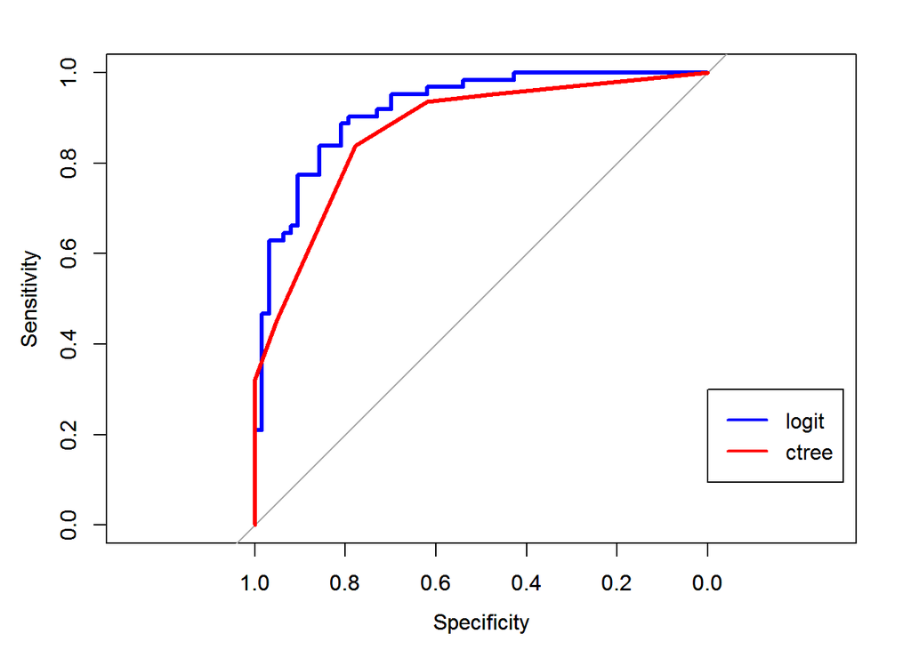

```r
legend(x=0, y=0.3, legend = c("logit", "ctree"), col = c("blue", "red"), lwd=c(2, 2))
```